# Biostatistics

V. Inácio de Carvalho & M. de Carvalho

We will start by reproducing the plots we have in slides 7 and 9 of the lectures (sampling distributions of $\widehat{\text{OR}}$ and $\log \widehat{\text{OR}}$). We will also make the corresponding plots for the sampling distributions of $\widehat{\text{RR}}$ and $\log \widehat{\text{RR}}$. The key is to remember that, under a cohort design, the entry $a$ in the $2\times 2$ contingency table (slide 3) follows a binomial distribution whose parameters are the number of exposed individuals and probability of disease given exposure. Similarly, the entry $c$ (in the same contingency table) also follows a binomial distribution whose parameters are, in turn, the number of individuals who are not exposed and the probability of disease given no exposure. We will be assuming that $p_1=\Pr(D\mid E) = 0.2$ and that $p_2=\Pr(D\mid \text{not } E) = 0.2$ and, further, that we have 50 individuals in the exposed group and another 50 individuals in the unexposed group. To make the results reproducible, I will be fixing the seed. The code is as follows.

```r
n_exp <- 50
n_unexp <- 50
p1 <- 0.2
p2 <- 0.2

nsim <- 1000
OR <- RR <- numeric(nsim)

set.seed(123)
for(i in 1:nsim){
  a <- rbinom(1, n_exp, p1)
  c <- rbinom(1, n_unexp, p2)
  b <- n_exp - a
  d <- n_unexp - c
  OR[i] <- (a*d)/(b*c)
  RR[i] <- (a/(a+b))/(c/(c+d))
}

df_OR <- data.frame("Mean" = c(mean(OR), mean(log(OR))),
                 "Median" = c(median(OR), median(log(OR))),
                 "Min" = c(min(OR), min(log(OR))),
                 "Max" = c(max(OR), max(log(OR)))
                 )

rownames(df_OR) <- c("OR", "log OR")
knitr::kable(df_OR, escape = FALSE, digits = 3,
             caption = "Summary statistics of the sampling distributions of the OR and log OR")
```

Summary statistics of the sampling distributions of the OR and log OR

|  | Mean | Median | Min | Max |
| --- | --- | --- | --- | --- |
| OR | 1.193 | 1 | 0.202 | 6.769 |
| log OR | 0.023 | 0 | -1.599 | 1.912 |

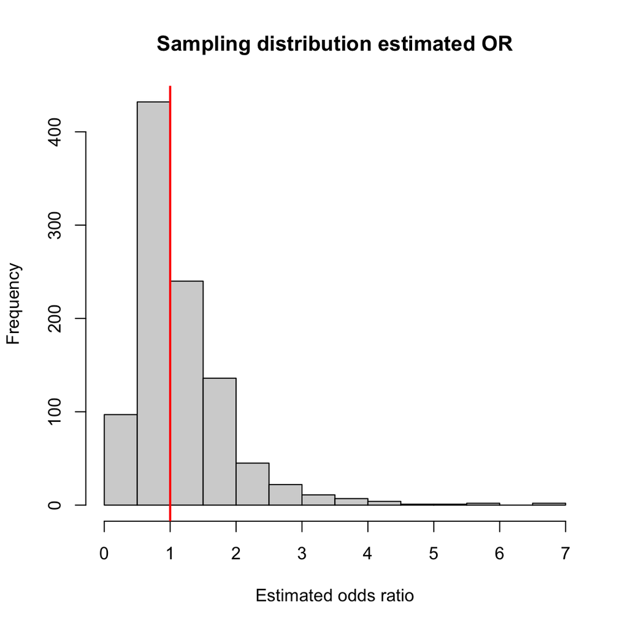

```r
hist(OR, nclass = 20, xlab = "Estimated odds ratio",
     ylab = "Frequency", main = "Sampling distribution estimated OR")
abline(v = 1, lwd = 2, col = "red")
```

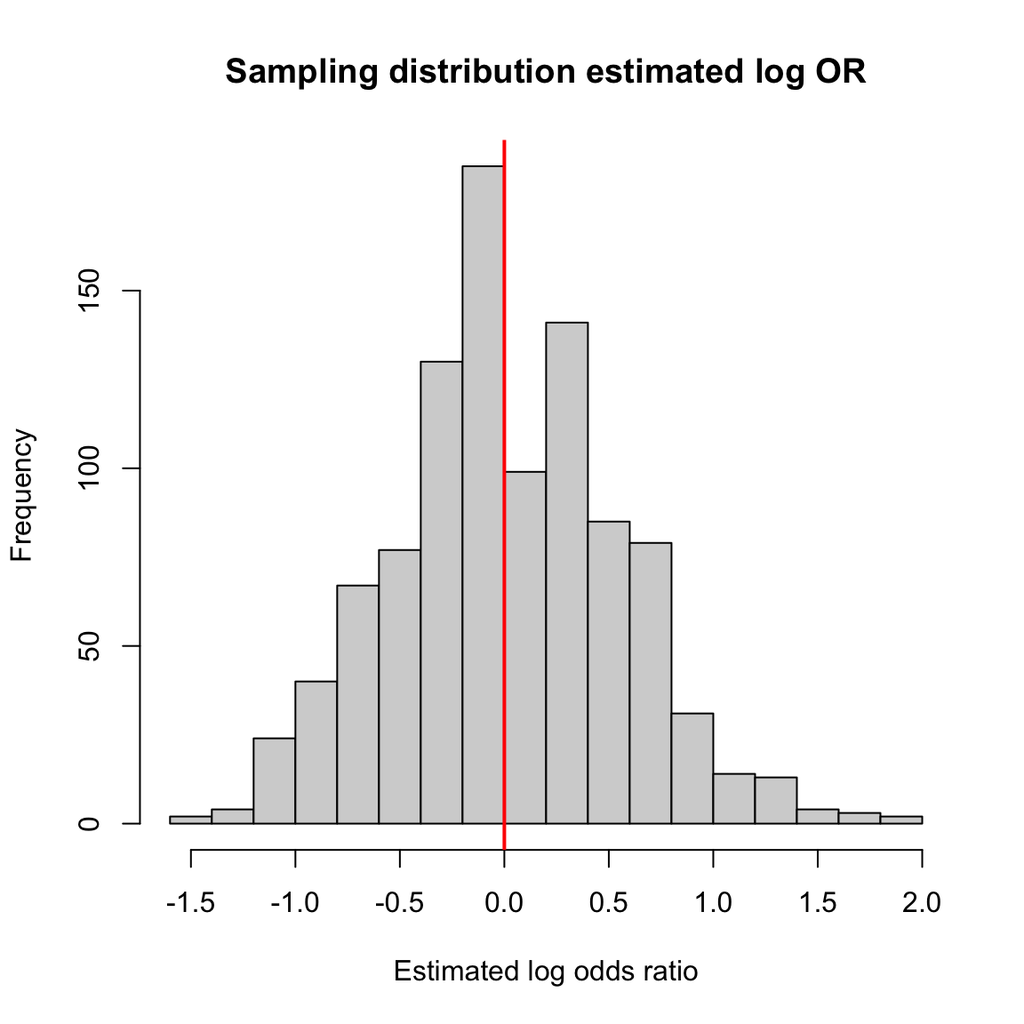

```r
hist(log(OR), nclass = 20, xlab = "Estimated log odds ratio",
     ylab = "Frequency", main = "Sampling distribution estimated log OR")
abline(v = 0, lwd = 2, col = "red")
```

```r
df_RR <- data.frame("Mean" = c(mean(RR), mean(log(RR))),
                 "Median" = c(median(RR), median(log(RR))),
                 "Min" = c(min(RR), min(log(RR))),
                 "Max" = c(max(RR), max(log(RR)))
                 )

rownames(df_RR) <- c("RR", "log RR")
knitr::kable(df_RR, escape = FALSE, digits = 3,
             caption = "Summary statistics of the sampling distributions of the RR and log RR")
```

Summary statistics of the sampling distributions of the RR and log RR

|  | Mean | Median | Min | Max |
| --- | --- | --- | --- | --- |
| RR | 1.129 | 1 | 0.250 | 5.500 |
| log RR | 0.019 | 0 | -1.386 | 1.705 |

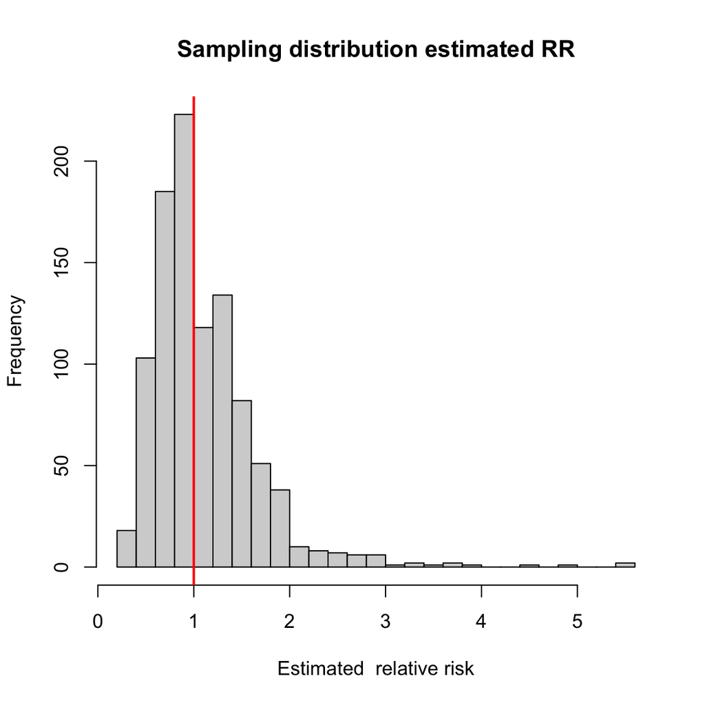

```r
hist(RR, nclass = 20, xlab = "Estimated  relative risk",
     ylab = "Frequency", main = "Sampling distribution estimated RR")
abline(v = 1, lwd = 2, col = "red")
```

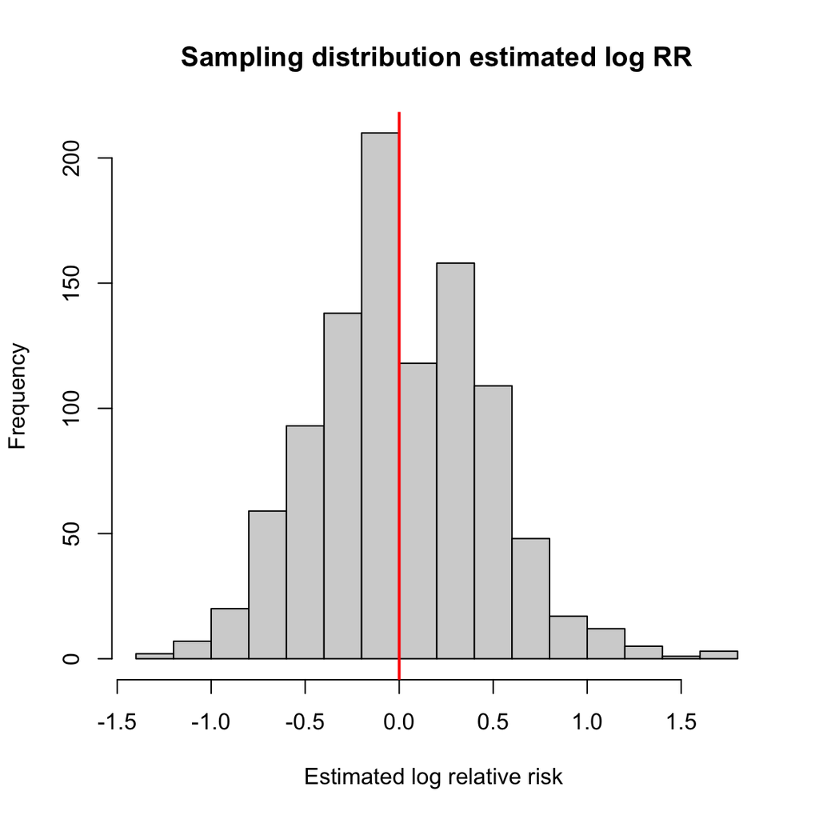

```r
hist(log(RR), nclass = 20, xlab = "Estimated log relative risk ",
     ylab = "Frequency", main = "Sampling distribution estimated log RR")
abline(v = 0, lwd = 2, col = "red")
```

```r
require(epiR)
data <- c(62, 76, 5, 55)
epi.2by2(data, method = "case.control", conf.level = 0.95, units = 100,
         interpret = TRUE, outcome = "as.columns")
```

```
##              Outcome +    Outcome -      Total                       Odds
## Exposed +           62           76        138        0.82 (0.59 to 1.12)
## Exposed -            5           55         60        0.09 (0.02 to 0.20)
## Total               67          131        198        0.51 (0.37 to 0.68)
##
## Point estimates and 95% CIs:
## -------------------------------------------------------------------
## Exposure odds ratio                            8.97 (3.38, 23.79)
## Attrib fraction (est) in the exposed (%)      88.75 (69.69, 96.69)
## Attrib fraction (est) in the population (%)   82.23 (57.71, 92.53)
## -------------------------------------------------------------------
## Uncorrected chi2 test that OR = 1: chi2(1) = 25.013 Pr>chi2 = <0.001
## Fisher exact test that OR = 1: Pr>chi2 = <0.001
##  Wald confidence limits
##  CI: confidence interval
##  Measures of association strength:
##  The exposure odds among cases was 8.97 (95% CI 3.38 to 23.79) times greater than exposure odds among controls.
##
##  Measures of effect in the exposed:
##  88.7% of outcomes in the exposed were attributable to exposure (95% CI 69.7% to 96.7%).
##
##  Measures of effect in the population:
##  82.2% of outcomes in the population were attributable to exposure (95% CI 57.7% to 92.5%).
```

```r
require(epitools)
oddsratio(data, method = "wald", conf = 0.95, correct = FALSE)
```

```
## $data
##           Outcome
## Predictor  Disease1 Disease2 Total
##   Exposed1       62       76   138
##   Exposed2        5       55    60
##   Total          67      131   198
##
## $measure
##           odds ratio with 95% C.I.
## Predictor  estimate    lower    upper
##   Exposed1 1.000000       NA       NA
##   Exposed2 8.973684 3.384777 23.79093
##
## $p.value
##           two-sided
## Predictor    midp.exact fisher.exact   chi.square
##   Exposed1           NA           NA           NA
##   Exposed2 1.225344e-07 1.967011e-07 5.693107e-07
##
## $correction
## [1] FALSE
##
## attr(,"method")
## [1] "Unconditional MLE & normal approximation (Wald) CI"
```